# Evaluating Numerical Fidelity in Financial Documents: A Comparative Analysis of Naive and Table-Aware Dual-Branch RAG Architectures

A Capstone Project in Data Science

Author

Crystal Shin, Gredy Garrido, and Nick Lopez

Published

View Presentation Slides

## Introduction

### The Real-World Risk: Why Tiny AI Mistakes Matter

Today, many companies use AI assistants to quickly find information buried in their internal reports. These systems are great at summarizing emails or articles, but they often fail when reading financial tables (Guo, Geng, and Mao 2026). Imagine an employee asking the AI system for a company’s total debt from a dense financial document. In a typical financial table, a number like “450” might mean $450 million if it is listed under a header that says “figures in millions.” Because standard AI reads text in a straight line from left to right, it can lose track of those important headers and labels. It might report the debt as just $450 or link the number to the wrong year entirely. In the world of finance, a mistake like this isn’t just a small typo; it can lead to massive losses or legal trouble.

This problem is commonly known as the gap between what a table says and what the AI actually understands. The dominant approach for building document-querying AI systems is Retrieval-Augmented Generation (RAG) (Malali 2025) — a method that retrieves relevant passages from a document library before generating a response, grounding the AI’s answer in real source material. While RAG has proven effective for regulatory compliance, audit reporting, and other text-heavy financial tasks, its standard pipeline was designed for narrative prose and breaks down when applied to structured tables. This paper compares a standard RAG baseline against a table-aware pipeline on a corpus of real financial reports, introducing a Numerical Atomic Verification (NAV) metric to explicitly measure numerical fidelity in model outputs.

### The Core Problem Statement: The Structural Evidence Gap

The core issue is that standard AI systems struggle to read complex financial tables. While these systems are great at reading plain text, they fail when processing financial data because they try to parse tables line by line, as if they were sentences (Guo, Geng, and Mao 2026). We refer to this as the Structural Evidence Gap. This leads to two main problems:

1. **Context Loss**: When the AI system breaks text into smaller chunks, it separates numbers from their labels (like headers or rows). This means the AI loses track of what the numbers actually represent.
2. **Formatting Issues**: Because standard tools read tables linearly, they jumble the data, mixing up different rows and columns.

While these AI systems work well for general reading, they fail when analyzing complex financial records in which answers are hidden across multiple structured tables.

### Overview of Approach: Table-Aware Dual-Branch RAG

To solve the problems described above, this paper compares two approaches:

- **Architecture A (Naive RAG)**: This standard method uses simple linear PDF reading and basic semantic search, which often misses the structure of financial tables.
- **Architecture B (Table-Aware Dual-Branch RAG)**: This is our proposed solution, which helps retain structural lineage between document context and table information.

Our approach includes five key steps:

1. **Bifurcated Ingestion**: The system separates narrative text from tabular data at the beginning, ensuring tables are preserved as structured data rather than flattened into plain text.
2. **Chunking (Narrative and SRSE)**: Parsing narrative text into context-aware chunks and converting table rows into Single-Row Single-Embedding (SRSE) representations. Each table row is stored as an individual record, enriched with its column/row labels (Liu and Leong 2026). This ensures the AI system always knows exactly what a number represents (e.g., Fiscal Year 2025 vs. “2025”).
3. **Hybrid Indexing**: Storing narrative text and table rows in separate, organized lists to maintain structural metadata.
4. **Dual-Channel Retrieval with Table Reconstruction**: Searching both branches simultaneously and automatically reconstructing full tables when a row match is found.
5. **Generation**: Using the structured, clear data to produce accurate, reliable answers.

The pipeline is benchmarked against standard industry metrics to prove its effectiveness in handling complex financial documents.

## Methods

To evaluate the impact of preserving document structure on retrieval accuracy, this study compares two contrasting RAG pipelines on a corpus of annual financial statements. We compare a standard naive RAG baseline (**Architecture A**), which flattens document layouts into linear text streams, against a Table-Aware Dual-Branch RAG pipeline (**Architecture B**), designed to isolate and process narrative and tabular elements down separate, optimized pathways. By evaluating both architectures against a validation suite of financial queries, we evaluate the impact of layout preservation on numerical retrieval accuracy and context coherence.

### Architecture A: Naive RAG

This architecture serves as our baseline RAG methodology. It represents the standard for text-heavy question-and-answer (QA) systems, which treat all document elements (paragraphs, footnotes, tables, etc.) as a continuous sequence of characters (Lewis et al. 2020). This method is one of the original techniques of RAG and gained popularity shortly after the widespread adoption of ChatGPT (Gao et al. 2023). This approach can be broken down into 4 stages: ingestion, indexing, retrieval, and generation.

```
flowchart TB
    A_Ingest["Step 1: Ingestion"]
    A_Ingest --> A_Chunk["Step 2: Indexing"]
    A_Chunk --> A_Index["Step 3: Retrieval"]
    A_Index --> A_Retrieve["Step 4: Generation"]

    classDef nodeA fill:#ede9fe,stroke:#7c3aed,stroke-width:1.5px,color:#1e1b4b
    class A_Ingest,A_Chunk,A_Index,A_Retrieve nodeA
```

Architecture A — Naive RAG

#### Step 1: Ingestion

The first step of this process is to ingest each PDF in the corpus. We do this by utilizing the `pdfplumber` library to extract the raw text. It reads the document sequentially, top to bottom, left to right, ignoring the visual bounding boxes of tables. This known behavior can lead to the Structural Evidence Gap (Islam et al. 2023). For example, a table row shown below will simply become a string of characters without any reference to the column headings because the heading and row-level data are reported as one continuous string of text in the document.

**Table:**

| Year | Debt | Assets |
| --- | --- | --- |
| 2025 | $450M | $800M |
| 2026 | $440M | $816M |

**Naive RAG Flattened Text:** *“Year Debt Assets 2025 $450M $800M 2026 $440M $816M”*

#### Step 2: Indexing

The first step of the indexing process is to parse the flattened text into chunks. We do this using our `index_naive_chunks`. This process takes three parameters: `text`, `chunk_size`, and `chunk_overlap`. The flattened text from the ingestion process is passed to the `text` parameter. We can then define `chunk_size` and `chunk_overlap`, or use the default values of `512` and `50`, respectively. We use `RecursiveCharacterTextSplitter` from `LangChain` as our splitting algorithm. `Chunk_size` is used as the upper limit for chuck size. In other words, a chunk will never exceed the defined `chunk_size`, but may be smaller. The `chunk_overlap` ensures that themes and ideas are not split between chunks, reducing the risk of meaningful context being lost. We measure the length of each chunk by word count; this is defined in the `length_function`. The `separators` parameter provides a mechanism for controlling document fragmentation. By establishing a prioritized list of delimiters, we guide the algorithm on how to partition the content effectively. For our naive approach, we use a simpler method, parsing the text by space first and then by character, `[" ", ""]`. Following the initial text split, the `length_function` evaluates the dimensions of each chunk. If a segment exceeds the specified `chunk_size`, it undergoes further partitioning. This iterative process utilizes the separator hierarchy to subdivide the text until all chunks align with the required size constraints. Chunks are then added to a list and tagged with metadata from the source document.

**Note**

`Chunk_size = 512` and `chuck_overlap = 50` are the standard sizes used across the industry. `Chunk_size` of `512` is a good range to allow for a full complete thought, but focused enough to represent a single semantic concept. `Chunk_overlap` of `50` follows the rule of thumb of 10-15% of chunk size (Microsoft Learn 2026). This is large enough to capture typical sentence lengths to carry over themes without bloating the vector database with too much duplicate text.

**Architecture A** uses a simple method of splitting text by spaces and characters. Because this method doesn’t recognize where paragraphs or lines actually end, it often incorrectly breaks tables apart. Instead of keeping tables intact, the method randomly cuts them up based on character counts. This means a row or column might get split in the middle, separating numbers from their labels. As a result, context may be lost when trying to understand the financial data.

#### Step 3: Retrieval

The logic for our baseline search is defined within the `retrieve_naive()` function. This procedure accepts the natural-language input via the `query` parameter, ingests the collection of document segments generated during indexing through `indexed_chunks`, and determines the quantity of retrieved evidence based on the `top_k` specification. The final phase of the retrieval process involves aggregating the identified evidence segments into a consolidated context window. This curated information is then transmitted to the generative model, providing the factual grounding necessary for producing a high-fidelity response for the end user or downstream LLM applications.

Prior to executing any semantic matching operations between the natural-language query and the corpus, the textual data must undergo a normalization process. We utilize a dedicated `tokenize()` function to ensure uniform casing, eliminate non-alphanumeric noise, and isolate individual semantic tokens. This preprocessing phase is critical for maintaining high-fidelity results during subsequent similarity search procedures.

```python
from src.retrieval import tokenize

original_query = "Operating Revenue: $110M"
tokenized_query = tokenize(original_query)
print(f'Original query: {original_query}\nTokenized query: {tokenized_query}')
```

```
Original query: Operating Revenue: $110M
Tokenized query: ['operating', 'revenue', '110m']
```

After normalizing both the natural-language query and the document corpus, the pipeline performs a semantic comparison to evaluate the similarity between the two datasets using `compute_bm25_scores()`. We implement the `BM25Okapi` algorithm, sourced from the `rank_bm25` library, to calculate these relevance scores. This probabilistic model assigns a weight to each text segment based on term frequency and inverse document frequency, effectively prioritizing chunks that contain rare, highly descriptive keywords over those with common linguistic fillers (Park 2025). To refine the retrieval accuracy, the system exposes the `k1` and `b` hyperparameters. The `k1` parameter provides a saturation function that dampens the influence of term frequency; this prevents a segment from being disproportionately weighted simply because a query term appears multiple times. Furthermore, the `b` parameter introduces length normalization, adjusting the score to ensure that expansive text blocks do not dominate the results simply by virtue of their larger word counts, thereby maintaining parity across varying chunk dimensions.

The general BM25 Okapi scoring formula is represented as:

$$\text{score}(D, Q) = \sum_{i=1}^{n} \text{IDF}(q_i) \cdot \frac{f(q_i, D) \cdot (k_1 + 1)}{f(q_i, D) + k_1 \cdot \left(1 - b + b \cdot \frac{|D|}{\text{avgdl}}\right)}$$

Where:

- $f(q_i, D)$ is the term frequency of query term $q_i$ in document (chunk) $D$.
- $|D|$ is the length of document $D$ in words.
- $\text{avgdl}$ is the average document length across the entire corpus.
- $k_1$ is a scaling hyperparameter tuning term frequency saturation.
- $b$ is a hyperparameter managing document length normalization.
- $\text{IDF}(q_i)$ represents the Inverse Document Frequency of query term $q_i$, computed as:

$$\text{IDF}(q_i) = \ln \left( \frac{N - n(q_i) + 0.5}{n(q_i) + 0.5} + 1 \right)$$

(where $N$ is the total number of documents in the corpus, and $n(q_i)$ is the number of documents containing $q_i$)(Park 2025).

#### Step 4: Generation

The final step in **Architecture A** is Generation, where the system converts the information found into a plain-language answer. The top 5 text chunks are combined and sent to the LLM (`Gemini 3.5-flash`), which acts as a financial assistant. The Large Language Model (LLM) is instructed to use only the provided information or provide a fallback if the answer is missing. This ensures that the LLM’s focus is on grounded information and reduces the risk of hallucinations (Asai et al. 2024). Because this method treats tables like simple text and loses their headers, the LLM often receives scrambled data. This forces the model to piece together disjointed numbers, which could lead to wrong answers or hallucinations. In addition to the context, the user’s query is also injected into the final prompt sent to the LLM.

Below is the prompt template used by the generative step:

```
You are a helpful assistant analyzing financial documents.
Answer the user's question using only the provided context.
If the answer is not in the context, say "I cannot answer this based on the provided documents.".

Context:
{Retrieved Context Chunks}

Question:
{User Query}
```

### Architecture B: Table-Aware Dual-Branch RAG

This architecture is our proposed solution designed to overcome the structural layout limitations inherent in a standard naive pipeline. Rather than flattening documents into a single text stream, **Architecture B** employs a dual-branch method that separates narrative text from structured tables during ingestion. By processing table structures with a **Single-Row Single-Embedding (SRSE)** representation and reconstructing the complete table context at query time, this pipeline preserves the semantic linkage among row elements, column headers, and financial units. This dual-branch approach comprises 5 distinct stages: bifurcated ingestion, chunking (narrative and SRSE), hybrid indexing, dual-channel retrieval with table reconstruction and generation.

```
flowchart TB
    B_Ingest["Step 1: Bifurcated Ingestion"]
    B_Ingest -->|Prose| B_Text["Step 2a: Narrative Chunking"]
    B_Ingest -->|Tables| B_SRSE["Step 2b: SRSE Row Chunking"]
    B_Text --> B_Index["Step 3: Hybrid Index"]
    B_SRSE --> B_Index
    B_Index --> B_Retrieve["Step 4a: Dual-Channel Retrieval"]
    B_Retrieve --> B_Recon["Step 4b: Table Reconstruction"]
    B_Recon --> B_LLM["Step 5: Generation"]

    classDef nodeB fill:#dbeafe,stroke:#2563eb,stroke-width:1.5px,color:#1e3a5f
    class B_Ingest,B_Text,B_SRSE,B_Index,B_Retrieve,B_Recon,B_LLM nodeB
```

Architecture B — Table-Aware Dual-Branch RAG

#### Step 1: Bifurcated Ingestion

The first step in **Architecture B** is Bifurcated Ingestion, which separates narrative prose from tabular structures using the `parse_document_table_aware` pipeline. Tables are parsed using `camelot`, and any text found in the tables is excluded from the prose chunks, preventing table cell contents from being included.

To maintain structural integrity, a few preprocessing steps are required. Multi-row table headers are consolidated into a single row to reduce the number of invalid rows. Schema context is preserved by taking the last non-empty value in each column. Additionally, cells undergo delimiter separation, where internal newlines are removed, and content is joined using a pipe (|) delimiter. Finally, currency cleanups are performed using regex to eliminate extraneous whitespace between currency symbols and values, and to merge any isolated dollar signs back into their respective cell data.

This bifurcated extraction creates two isolated document branches (prose text and structured table grids), ensuring that layout-heavy financial information is stored as clean, structured tables rather than a linear prose stream.

#### Step 2a: Narrative Chunking

In this step, the continuous narrative text is parsed into chunks, which is conceptually similar to the indexing process in **Architecture A**. The same target dimensions are utilized (chunk_size = 512, chunk_overlap = 50) and splitting library. However, it introduces two key deviations:

1. **Structural Delimiters**: While **Architecture A** flattens and splits the text using basic space and character delimiters (`[" ",""]`), **Architecture B** employs a prioritized separator hierarchy `["\n\n", "\n", " ",""]`. This forces the splitting algorithm to partition text at natural paragraph and sentence boundaries first, keeping reading context intact rather than severing blocks mid-sentence.
2. **Metadata Preservation**: In **Architecture A**, page coordinates are lost during the text flattening, resulting in all chunks being tagged as `"page: unknown"`. In **Architecture B**, page indicators (e.g. `"--- Page X (text) ---"`) are parsed and stripped before splitting, allowing every resulting prose chunk to carry precise page coordinates in its metadata.

#### Step 2b: SRSE Row Chunking

Within our **Single-Row Single-Embedding (SRSE)** step, we process tables one row at a time rather than breaking them up by size. First, table column headers are identified. Then, each row is converted into a structured string that links every cell value to its corresponding header (e.g., “Header: Value”). It also labels every row with its specific table and page number. By attaching column headers to every row, the system ensures that numbers stay connected to their labels, which prevents the data confusion that may be present in **Architecture A**. This method is intended to preserve the full semantic meaning of each row, making it easier for the model to understand the table’s layout.

For example, given a raw table row:

| Year | Debt | Assets |
| --- | --- | --- |
| 2025 | $450M | $800M |

The pipeline parses the cells and maps them dynamically. Below is an example of the formatting function in action:

```python
from src.indexing import _format_row_as_srse

# Table details extracted during ingestion
table_id = "Page_1_Table_1"
headers = ["Year", "Debt", "Assets"]
rows_data = ["2025", "$450M", "$800M"]

# Generate Single-Row Single-Embedding (SRSE) representation
srse_string = _format_row_as_srse(rows_data, headers, table_id)

print(srse_string)
```

```
Table: Page_1_Table_1 | Year: 2025 | Debt: $450M | Assets: $800M
```

The `_format_row_as_srse` function converts each table row into a clear, searchable text string. It takes the row’s data, the column headers, and a unique table ID as input. It then builds a string that pairs each cell value with its matching header (e.g., “Header: Value”). If a header is missing, it assigns a temporary name. Finally, it combines the table ID and these pairs into a single line, separated by pipes (`|`). This process ensures each row stays correctly linked to its labels.

#### Step 3: Hybrid Index

Step 3 is the **Hybrid Index**. Instead of using one flat list, it keeps narrative text and table rows in two separate lists. This helps the system stay organized. Each list keeps track of important details, like which page the text is on or which table a row belongs to. By keeping this information separate, the system can easily search both types of content and perfectly put tables back together later. This indexing methodology will become critical for **Step 4**.

#### Step 4a: Dual-Channel Retrieval

In this step, the system searches both narrative text and table rows simultaneously. It uses the same **BM25 search** function (`compute_bm25_scores`) as in **Architecture A** to rank chunks by how well they match the user’s question. When it finds a match:

- Narrative text is added directly to the final context window.
- If a table row is found, it acts as a signal to reconstruct the full table using its `table_id`.

The system then skips any other rows from that same table to avoid repeating information and to keep the answer concise.

#### Step 4b: Table Reconstruction

The **Table Reconstruction** step ensures the LLM sees the big picture. When the system finds a single row that matches the user’s query, it automatically looks for the rest of that table. It gathers all related rows, restores their original order, and reattaches the correct column headers. Instead of just looking at a tiny fragment of data, the LLM is given the complete, formatted table. This helps the system understand the full context of the information before it generates an answer.

Below is a demonstration of how the table reconstruction logic compiles scattered single-row semantic table chunks back into a coherent, structured Markdown table layout:

```python
import json
from src.retrieval import reconstruct_table

# Load the real table-aware indexed document index (SRSE format)
with open("data/indexed/table-aware_SRSE.json", "r", encoding="utf-8") as f:
    table_row_index = json.load(f)

# Reconstruct a real table from the indexed rows (e.g. Page_12_Table_1 from FY-21-22)
reconstructed_markdown = reconstruct_table(
    table_id="Page_12_Table_1",
    filename="UWF-Financial-Statement-FY-21-22.pdf",
    table_row_index=table_row_index
)

print(reconstructed_markdown)
```

```
| (In Thousands)                               | For the Fiscal Years   | 2021-22   |    | 2020-21   |
|----------------------------------------------|------------------------|-----------|----|-----------|
| Operating Revenues                           |                        | $93,848   |    | $84,893   |
| Less, Operating Expenses                     |                        | 232,842   |    | 243,803   |
| Operating Loss                               |                        | (138,994) |    | (158,910) |
| Net Nonoperating Revenues                    |                        | 145,066   |    | 131,516   |
| Income (Loss) Before Other Revenues          |                        | 6,072     |    | (27,394)  |
| Other Revenues                               |                        | 7,804     |    | 1,453     |
| Net Increase (Decrease) In Net Position      |                        | 13,876    |    | (25,941)  |
| Net Position, Beginning of Year              |                        | 81,897    |    | 107,838   |
| Adjustment to Beginning Net Position (1)     |                        | (111)     |    | -         |
| Net Position, Beginning of Year, as Restated |                        | 81,786    |    | 107,838   |
| Net Position, End of Year                    |                        | $95,662   |    | $81,897   |
```

#### Step 5: Generation

This step is where the system generates the final answer. This step uses the same process as **Architecture A**. The big difference is what we feed the LLM. Instead of giving it messy, scrambled text, we give it clear narrative text and organized tables. Because the data is structured and clean, the AI can easily read the numbers, match them to the right categories, and provide highly accurate, reliable answers.

### Evaluation

To compare the performance of **Naive RAG** (**Architecture A**) and our **Table-Aware Dual-Branch RAG** (**Architecture B**), we developed a structured evaluation framework. We used a set of practice questions to assess how accurately each method locates information and retrieves accurate financial data.

#### Evaluation Dataset and Question Tiering

The evaluation dataset consists of 60 benchmark questions designed to assess different cognitive levels of data extraction and reasoning from documents in our corpus. The queries are categorized into three distinct tiers:

[output not shown]

We selected 20 questions for each tier, totaling 60 questions. The questions were crafted to cover a range of financial topics found in the Annual Financial Reports, including revenues, expenditures, net position, and financial condition. This tiered approach allowed us to evaluate the RAG systems on progressively complex tasks, providing a comprehensive measure of their capabilities.

#### Ground Truth Construction

A curated ground-truth dataset (`data/eval/questions.csv`) serves as the benchmark for accuracy. For each of the 60 queries, the ground truth defines:

- **Expected Files**: The specific PDF files containing the factual evidence.
- **Expected Location (Pages)**: The precise page numbers where the information resides.
- **Expected Answer**: The exact numerical values representing the correct calculation, formatted to accommodate scale variations (e.g., raw numbers, thousands, or millions).

#### Evaluation Metrics

We use four metrics to measure how well each architecture finds the right information and how accurately it answers questions:

1. `PageHit`: This checks if the correct docuemnt and page is among the LLM’s top 5 results. It is a simple “yes” or “no” score; either the LLM found the right source (1) or it didn’t (0).

$$\text{PageHit}(C_R, E) = \max_{c \in C_R} \mathbb{I}(\text{match}(c, E))$$

Where $C_R$ is the set of retrieved chunks, $E$ represents the expected ground-truth location, and $\mathbb{I}(\text{match}(c, E))$ is an indicator function outputting $1$ if chunk $c$ matches the expected location $E$ (by file name and page/table ID) and $0$ otherwise.

2. `PageHitPrecision`: This measures how well the retrieval step retrieves the results. It gives a higher score if the correct information appears at the very top of the list rather than further down. This helps us see how efficient the system is at surfacing the best evidence.

$$\text{PageHitPrecision} = \frac{1}{N_{hits}} \sum_{i=1}^{k} \left( \frac{\sum_{j=1}^{i} \mathbb{I}(c_j \in E)}{i} \times \mathbb{I}(c_i \in E) \right)$$

Where $c_i$ is the chunk at rank $i$, $\mathbb{I}(c \in E)$ indicates whether a chunk is a correct match, and $N_{hits} = \sum_{i=1}^{k} \mathbb{I}(c_i \in E)$ is the total number of hits in the top-$k$ (default $k=5$). If $N_{hits} = 0$, the precision is defined as $0$.

3. `NAVMetric` (Numerical Atomic Verification): This measures the accuracy of the actual answer. Since financial numbers can be written in different ways (like “$12.5M” vs. “12,500,000”), this tool standardizes the numbers and compares them to the primary ground-truth value. Instead of a binary score, it provides diminishing rewards for numbers rounded to the thousands or millions:

$$\text{NAV}(A_{gen}, y) = \max_{\hat{y} \in \text{Extract}(A_{gen})} \text{Reward}\left( \frac{|\hat{y} - y|}{|y|} \right)$$

Where $y$ is the primary ground-truth numerical value, $A_{gen}$ is the generated text answer, and $\text{Extract}(A_{gen})$ returns the set of scaled numerical candidates found in the text. The $\text{Reward}$ function outputs $1.0$ for near-exact matches ($\le 0.1\%$ error), $0.75$ for thousands rounding ($\le 0.5\%$ error), $0.5$ for millions rounding ($\le 5\%$ error), and $0.0$ otherwise.

4. `calculate_cea` (Conditional Extraction Accuracy): This measures the fraction of correctly answered questions given that the correct context was successfully retrieved (PageHit=1). It helps us understand the effectiveness of the LLM in extracting the correct answer from the retrieved context:

$$\text{CEA} = \frac{\sum_{q \in Q} \text{NAV}_q \times \text{PageHit}_q}{\sum_{q \in Q} \text{PageHit}_q}$$

Where $Q$ is the set of all evaluation questions, and $\text{NAV}_q$ and $\text{PageHit}_q$ represent the respective metric scores for question $q$.

## Analysis and Results

### Data Exploration and Visualization

We chose to use a collection of the University of West Florida’s Annual Financial Statements as our corpus for our RAG experiment. These documents are ideal for our project due to their dense natural-language text combined with tabular objects containing numerical data.

**Important**

*Please Note*: There are other types of objects in these documents (i.e., graphs, charts, pictures, etc.), but they are outside the scope of this research.

```python
import pandas as pd

# Load data
df = pd.read_csv('data/corpus_statistics.csv')

# Add average rows per table
df['Avg_Rows_Per_Table'] = df['Total_Table_Rows'] / df['Total_Tables']

# list of columns
cols = ['Fiscal_Year', 'Total_Pages', 'Total_Text_Blocks',
        'Total_Tables', 'Total_Table_Rows', 'Avg_Rows_Per_Table']

# Generate markdown table
print(df[cols].round(0).to_markdown(index=False))
```

Table 1: Corpus Volume & Complexity

| Fiscal_Year | Total_Pages | Total_Text_Blocks | Total_Tables | Total_Table_Rows | Avg_Rows_Per_Table |
| --- | --- | --- | --- | --- | --- |
| FY 20-21 | 60 | 60 | 14 | 59 | 4 |
| FY 21-22 | 62 | 62 | 13 | 63 | 5 |
| FY 22-23 | 64 | 64 | 14 | 61 | 4 |
| FY 23-24 | 66 | 64 | 13 | 61 | 5 |
| FY 24-25 | 67 | 65 | 14 | 65 | 5 |

After we ingest and index the documents for the different architectures we are comparing, we can clearly see the difference between the two in the resulting chunks. Figure 1 compares the indexing granularity and chunk composition between **Architecture A (Naive RAG)** and **Architecture B (Table-Aware Dual-Branch RAG)**.

[interactive chart not shown]

Figure 1: Figure 1: Chunks Generated by Architecture

As shown above, **Architecture B** generates significantly more indexable chunks compared to **Architecture A**. This is because **Architecture A** uses a fixed-token linear chunking approach, compressing an entire +60 page document into ~45 coarse blocks. Meanwhile, **Architecture B** uses **SRSE** to isolate and index each row identified in each table, in addition to a fixed-token linear approach for the narrative text within each document.

Under the Naive RAG approach (**Architecture A**), the document structure is ignored. Dense table rows are flattened into raw text and grouped arbitrarily, potentially causing numbers to lose their headers and contextual labels. In contrast, the Dual-Branch approach (**Architecture B**) ensures that every single row is preserved as its own semantic unit, complete with column/row header tags, preventing structural jumbling and preserving numerical lineage.

### Results

To evaluate the numerical fidelity of our retrieval-augmented generation pipelines, we analyzed the performance of both **Architecture A (Naive RAG)** and **Architecture B (Table-Aware Dual-Branch RAG)** across all 60 queries in our benchmark dataset.

The chart below (Figure 2) visualizes the performance across four key metrics:

1. **PageHit Recall**: Did the system retrieve the correct source document and page?
2. **PageHit Precision**: How well did the system rank the correct source chunk within the top 5 results?
3. **NAV Accuracy**: Did the final generated answer contain the correct numerical value?
4. **Conditional Extraction Accuracy (CEA)**: Given that the correct context was successfully retrieved, did the LLM accurately extract the final numerical value?

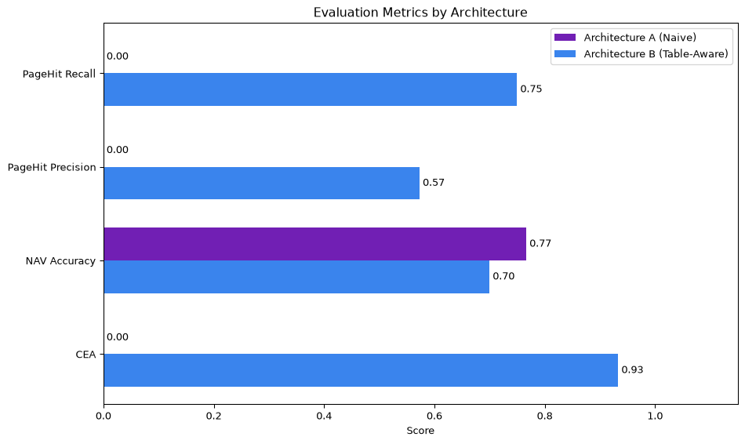

Figure 2: Performance Comparison: Naive vs. Table-Aware RAG

```python
import sys
import os
import pandas as pd
import matplotlib.pyplot as plt
import numpy as np

# Add project root to python path so we can import our modules
sys.path.insert(0, os.path.abspath("."))
from src.evaluation import calculate_cea

# Load the evaluation results
df = pd.read_csv('data/eval/eval_results.csv')

# Calculate the mean for basic metrics
naive_metrics = {
    'PageHit Recall': df['Naive_PageHit'].mean(),
    'PageHit Precision': df['Naive_PageHit_Precision'].mean(),
    'NAV Accuracy': df['Naive_NAV'].mean()
}

ta_metrics = {
    'PageHit Recall': df['TableAware_PageHit'].mean(),
    'PageHit Precision': df['TableAware_PageHit_Precision'].mean(),
    'NAV Accuracy': df['TableAware_NAV'].mean()
}

# Calculate Conditional Extraction Accuracy (CEA) using our metric function
results_list = df.to_dict('records')
naive_metrics['CEA'] = calculate_cea(results_list, 'Naive_PageHit', 'Naive_NAV')
ta_metrics['CEA'] = calculate_cea(results_list, 'TableAware_PageHit', 'TableAware_NAV')

# Data preparation for plotting
labels = list(naive_metrics.keys())
naive_values = [naive_metrics[label] for label in labels]
ta_values = [ta_metrics[label] for label in labels]

y = np.arange(len(labels))
height = 0.35

# Plot results in hbar
fig, ax = plt.subplots(figsize=(10, 6))
rects1 = ax.barh(y - height/2, naive_values, height, label='Architecture A (Naive)', color='#711fb4')
rects2 = ax.barh(y + height/2, ta_values, height, label='Architecture B (Table-Aware)', color='#3a84ed')

ax.set_xlabel('Score')
ax.set_title('Evaluation Metrics by Architecture')
ax.set_yticks(y)
ax.set_yticklabels(labels)
ax.set_xlim(0, 1.15)
ax.invert_yaxis()  # Metrics read from top to bottom
ax.legend(loc='upper right')

# Add data labels
for rect in rects1:
    width = rect.get_width()
    ax.annotate(f'{width:.2f}',
                xy=(width, rect.get_y() + rect.get_height() / 2),
                xytext=(3, 0),  # 3 points horizontal offset
                textcoords="offset points",
                ha='left', va='center')

for rect in rects2:
    width = rect.get_width()
    ax.annotate(f'{width:.2f}',
                xy=(width, rect.get_y() + rect.get_height() / 2),
                xytext=(3, 0),  # 3 points horizontal offset
                textcoords="offset points",
                ha='left', va='center')

fig.tight_layout()
plt.show()
```

**Note**

**Architecture A** is a linear chunking approach that compresses an entire document into fixed-size chunks. Therefore, it loses the document’s structure (e.g., page numbers, tables, and other objects). As a result, we are unable to compute `PageHitRecall`, `PageHitPrecision` and `CEA` for our naive RAG approach.

**PageHit Recall** and **PageHit Precision** provide insight into the retrieval process in **Architecture B** and how well it performs. From the **PageHit Recall** score, we can see that the relevant chunks are included in our context window; however, with a **PageHit Precision** score of $0.57$, we can deduce that the relevant chunks are ranked either 2nd or 3rd among the `top_k = 5`. This may lead to the LLM receiving a lot of noise in the context window, which in turn could be impacting the numerical fidelity of the response. A **CEA** score of $0.93$ confirms that, if the correct chunks are retrieved, the LLM performs well in providing the correct response. This reassures us that some tuning to the retrieval stage may be advantageous for **Architecture B**.

**NAV Accuracy** is the primary metric we focus on in this experiment. Contrary to our expectations, **Architecture A** performs better than **Architecture B** when evaluated solely on the numerical fidelity of the answers. The ~7% difference (4 questions) is not enough to completely dismiss **Architecture B**. In the next (Figure 3), we will explore the results by question tier to determine whether certain types of questions are better suited to one architecture than the other.

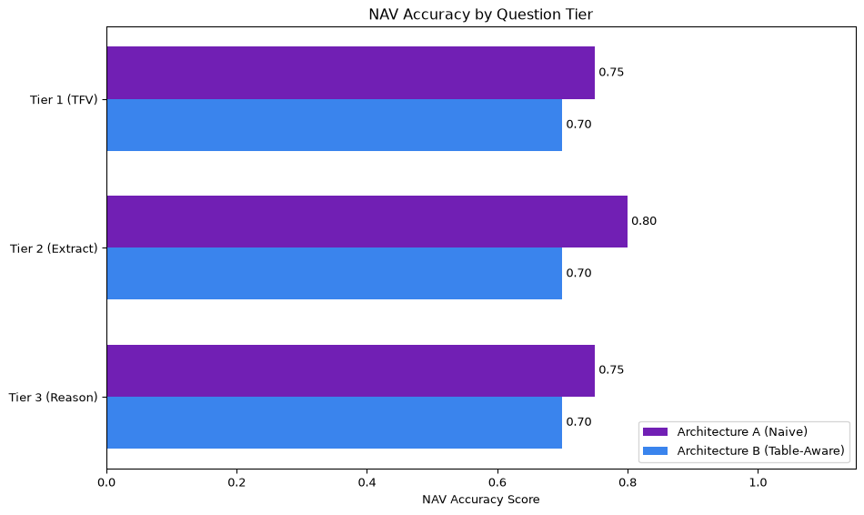

Figure 3: NAV Accuracy by Question Tier: Naive vs. Table-Aware RAG

```python
# Load the evaluation results
df = pd.read_csv('data/eval/eval_results.csv')

# Calculate mean NAV Accuracy grouped by Tier
tier_nav = df.groupby('Tier')[['Naive_NAV', 'TableAware_NAV']].mean()

# Extract labels and values
labels = tier_nav.index.tolist()
naive_values = tier_nav['Naive_NAV'].tolist()
ta_values = tier_nav['TableAware_NAV'].tolist()

y = np.arange(len(labels))
height = 0.35

# Plot results
fig, ax = plt.subplots(figsize=(10, 6))
rects1 = ax.barh(y - height/2, naive_values, height, label='Architecture A (Naive)', color='#711fb4')
rects2 = ax.barh(y + height/2, ta_values, height, label='Architecture B (Table-Aware)', color='#3a84ed')

ax.set_xlabel('NAV Accuracy Score')
ax.set_title('NAV Accuracy by Question Tier')
ax.set_yticks(y)
ax.set_yticklabels(labels)
ax.set_xlim(0, 1.15)
ax.invert_yaxis()  # Tiers read from top to bottom
ax.legend(loc='lower right')

# Add data labels
for rect in rects1:
    width = rect.get_width()
    ax.annotate(f'{width:.2f}',
                xy=(width, rect.get_y() + rect.get_height() / 2),
                xytext=(3, 0),  # 3 points horizontal offset
                textcoords="offset points",
                ha='left', va='center')

for rect in rects2:
    width = rect.get_width()
    ax.annotate(f'{width:.2f}',
                xy=(width, rect.get_y() + rect.get_height() / 2),
                xytext=(3, 0),  # 3 points horizontal offset
                textcoords="offset points",
                ha='left', va='center')

fig.tight_layout()
plt.show()
```

Figure 3 shows that the naive RAG method (**Architecture A**) outperformed our table-focused method (**Architecture B**) across all question types. This was surprising, especially for extraction questions (**Tier 2**) where we expected our method to be more accurate because it links headers to data. Instead, the simpler baseline method was more accurate. Our tests suggest the problem isn’t the LLM’s ability to generate answers, but how it finds the data. Because we broke the tables into single rows, they may lack important keyword context such as the report year or “UWF”, causing the search system to miss them $25\%$ of the time. However, when the system did find the right data, our new method was $93\%$ accurate, proving it works well once it has the correct information.

## Conclusion

This study compared a baseline linear-chunking RAG pipeline (**Architecture A**) against a proposed table-aware, dual-branch RAG pipeline (**Architecture B**) using a corpus of dense university financial reports.

### Key Findings

- **Unexpected Results**: Contrary to our expectations, the standard, simpler method (**Architecture A**) outperformed our custom table-focused method (**Architecture B**) across all question types. **Architecture A** was more accurate at finding financial numbers, even in complex tables.
- **The Search Problem**: Our deep dive showed that **Architecture B** struggled not because it couldn’t understand the information, but because it had trouble finding the right information. Since our proposed method focused on individual table rows, it missed important context, such as the company name, financial year, or table title. This caused it to fail to locate the correct context $25\%$ of the time.
- **Successful Generation**: However, when **Architecture B** found the right information, it was excellent at using it to answer questions, achieving a $93\%$ success rate. This signals the core generation process is very strong.

### Implications and Potential Solutions

Our findings reveal a key trade-off: breaking documents into smaller, more detailed pieces helps keep the original layout, but it makes it much harder for search tools to find the right information. Traditional search methods (like **BM25**) work best with larger, word-heavy blocks of text because they look for exact keyword matches.

To resolve this retrieval bottleneck in future iterations of table-aware RAG, we propose the following paths forward:

1. **Metadata Enrichment**: Pre-pending global document variables (e.g., reporting year, and table headers) to the text representation of each individual row chunk before indexing. This ensures row-level chunks retain searchability for macro-queries.
2. **Hybrid and Dense Retrieval**: Instead of just looking for exact keyword matches, we can switch to dense vector embeddings with a re-ranking layer (hybrid retrieval). These tools understand the meaning behind words, helping the system find information even if the specific words don’t match exactly in additon to the abilty to re-sort the retrieved chunks to the top of the context (Zhao et al. (2024)).
3. **Multi-Stage Search**: We can use a “parent-child” approach. The system would first find the right page (the parent), look for tabular data on that page, and then zoom in to find the specific table row (the child) within it, ensuring it doesn’t get lost in the search.

This research highlights a major challenge in building reliable AI for finance: it is hard to balance keeping data organized, making it easy for the system to find without losing context. While our **Table-Aware** method (**Architecture B**) provides highly accurate answers once it finds the right information, our results indicate that we need better search tools to handle complex data structures. By switching to smarter systems that better understand how documents are laid out, we can fix the problems caused by older, simpler search methods. This is crucial not only for creating better financial reports, but for ensuring that AI assistants are reliable, trustworthy tools for people when accuracy is a priority.

## References

Asai, Akari, Zeqiu Wu, Yizhong Wang, Avirup Sil, and Hannaneh Hajishirzi. 2024. “Self-RAG: Learning to Retrieve, Generate, and Critique Through Self-Reflection.” In *The Twelfth International Conference on Learning Representations*. https://openreview.net/forum?id=hSyW5go0v8.

Gao, Yunfan, Yun Xiong, Xinyu Gao, Kangxiang Jia, Jinliu Pan, Yuxi Bi, Yi Dai, Jiawei Sun, Meng Wang, and Haofen Wang. 2023. “Retrieval-Augmented Generation for Large Language Models: A Survey.” *arXiv Preprint arXiv:2312.10997*.

Guo, Zebin, Weidong Geng, and Ruichen Mao. 2026. “FT-RAG: A Fine-Grained Retrieval-Augmented Generation Framework for Complex Table Reasoning.” In *Proceedings of the 32nd ACM SIGKDD Conference on Knowledge Discovery and Data Mining (KDD ’26)*. ACM.

Islam, Pranab, Anand Kannappan, Douwe Kiela, Rebecca Qian, Nino Scherrer, and Bertie Vidgen. 2023. “FinanceBench: A New Benchmark for Financial Question Answering.” https://arxiv.org/abs/2311.11944.

Lewis, Patrick, Ethan Perez, Aleksandra Piktus, Fabio Petroni, Vladimir Karpukhin, Naman Goyal, Heinrich Küttler, et al. 2020. “Retrieval-Augmented Generation for Knowledge-Intensive NLP Tasks.” In *Advances in Neural Information Processing Systems*, 33:9459–74. Curran Associates, Inc.

Liu, Zhihao, and Waiyie Leong. 2026. “Table-Aware Row-Level RAG for Classical Chinese Understanding.” *Computers* 15 (4): 221. https://doi.org/10.3390/computers15040221.

Malali, N. 2025. “The Role of Retrieval-Augmented Generation (RAG) in Financial Document Processing.” *International Journal of Management Technology* 12 (3): 26–46. https://eajournals.org/ijmt/wp-content/uploads/sites/69/2025/04/The-Role-of-Retrieval-Augmented-Generation.pdf.

Microsoft Learn. 2026. “Chunk Large Documents for RAG and Vector Search in Azure AI Search.” https://learn.microsoft.com/en-us/azure/search/vector-search-how-to-chunk-documents.

Park, Emma. 2025. “Understanding Okapi BM25 — Document Ranking Algorithm.” Medium. https://medium.com/@readwith_emma/understanding-okapi-bm25-document-ranking-algorithm-70d81adab001.

Zhao, Wayne Xin, Jing Liu, Ruiyang Ren, and Ji-Rong Wen. 2024. “Dense Text Retrieval Based on Pretrained Language Models: A Survey.” *ACM Transactions on Information Systems* 42 (1): 1–60. https://doi.org/10.1145/3637870.